# Exploratory Analyses of Arkansas (REG, PRO), Michigan Lines (6, 7)

Alec Steep

20191210

## Setup the Environment

Long redundant output, skip this box–need to learn to remove

```r
################################################################################
##### Resources and Dependencies ###############################################
################################################################################

# Set the working directory
WD <- '/Users/Alec/Documents/Bioinformatics/germplasm_collab/20191205_pilot-snp-compare_steep'
#setwd(WD)

# Load the dependencies
#source("https://bioconductor.org/biocLite.R")
#BiocManager::install("UpSetR")
#install.packages("doSNOW")

# Load dependencies
pacs...man <- c("tidyverse","data.table","R.utils","ggpubr","plyr","readxl", "GenomicRanges","BSgenome","rtracklayer","NAM","phylogram","fields","RColorBrewer","mapplots","LEA","adegenet","stringi","ggplot2","snow","doSNOW","parallel","UpSetR")
lapply(pacs...man, FUN = function(X) {
        do.call("library", list(X))
})
```

[output not shown]

[output cut: 233 more lines]

```r
############################################################
##### Functions ############################################
############################################################

# Make the 'not in' operator
'%!in%' <- function(x,y) {
        !('%in%'(x,y))
}

# Capture the Date
date <- format.Date( Sys.Date(), '%Y%m%d' )
auth <- "steep"

## explicit gc, then execute `expr` `n` times w/o explicit gc, return timings (~"Jenny Bryan, updating work of Winston Chang")
benchmark <- function(n = 1, expr, envir = parent.frame()) {
        expr <- substitute(expr)
        gc()
        map(seq_len(n), ~ system.time(eval(expr, envir), gcFirst = FALSE))
}
```

## Load Data

##### Data Files to Load:

- Arkansas SNPs: Progressor, Regressor
- Michigan SNPs: Line 6, Line 7

```r
################################################################################
#####     Load & Clean Data      ###############################################
################################################################################

# Arkansas & Michigan SNPs
######################

# Load the annotated SNP file
L67RP_anne_file <- "./data/20191209_L67RP-annotations-quantitative_steep.txt"
L67RP_anne_file <- paste0(WD,"/data/20191209_L67RP-annotations-quantitative_steep.txt")
# xls files
L67RP_anne <- read.table(L67RP_anne_file,
                          sep = '\t', header = TRUE, check.names = FALSE) %>%
        as_tibble()
```

### Genotypes have been annotated with VEP & SIFT

Further cleaning is required, but global perspective will be indicative for pilot

```r
# Examine data
```

##### Dataset Dimensions and Sample Ouptut (6 rows)

```r
dim(L67RP_anne)
```

```
## [1] 23193    14
```

```r
head(L67RP_anne)
```

```
## # A tibble: 6 x 14
##   CHROM    POS REF   ALT   STRAND CONSEQUENCE IMPACT SYMBOL SIFT  GT    LINE_6
##   <int>  <int> <fct> <fct>  <int> <fct>       <fct>  <fct>  <fct> <fct>  <dbl>
## 1     1 1.48e7 C     T         -1 synonymous… LOW    SLC26… ""    1/1        1
## 2     1 1.48e7 C     T          1 downstream… MODIF… CBLL1  ""    1/1        1
## 3     1 1.48e7 G     A         -1 intron_var… MODIF… SLC26… ""    1/1        1
## 4     1 1.48e7 G     A          1 downstream… MODIF… CBLL1  ""    1/1        1
## 5     1 1.48e7 T     C         -1 intron_var… MODIF… SLC26… ""    1/1        1
## 6     1 1.48e7 T     C          1 downstream… MODIF… CBLL1  ""    1/1        1
## # … with 3 more variables: LINE_7 <dbl>, REG <dbl>, PRO <dbl>
```

##### Dataset Structure and Summary

```r
str(L67RP_anne)
```

```
## Classes 'tbl_df', 'tbl' and 'data.frame':    23193 obs. of  14 variables:
##  $ CHROM      : int  1 1 1 1 1 1 1 1 1 1 ...
##  $ POS        : int  14833321 14833321 14833339 14833339 14833364 14833364 14833367 14833367 14833455 14833455 ...
##  $ REF        : Factor w/ 4 levels "A","C","G","T": 2 2 3 3 4 4 1 1 3 3 ...
##  $ ALT        : Factor w/ 17 levels "A","A,*","A,C",..: 13 13 1 1 7 7 7 7 7 7 ...
##  $ STRAND     : int  -1 1 -1 1 -1 1 -1 1 -1 1 ...
##  $ CONSEQUENCE: Factor w/ 13 levels "3_prime_UTR_variant",..: 12 3 5 3 5 3 5 3 5 3 ...
##  $ IMPACT     : Factor w/ 3 levels "LOW","MODERATE",..: 1 3 3 3 3 3 3 3 3 3 ...
##  $ SYMBOL     : Factor w/ 103 levels "","ABHD2","ADPGK",..: 82 14 82 14 82 14 82 14 82 14 ...
##  $ SIFT       : Factor w/ 64 levels "","deleterious_low_confidence(0.02)",..: 1 1 1 1 1 1 1 1 1 1 ...
##  $ GT         : Factor w/ 6 levels "0/0","0/1","1/1",..: 3 3 3 3 3 3 3 3 3 3 ...
##  $ LINE_6     : num  1 1 1 1 1 1 1 1 1 1 ...
##  $ LINE_7     : num  1 1 0 0 0 0 0 0 0 0 ...
##  $ REG        : num  1 1 1 1 1 1 1 1 0 0 ...
##  $ PRO        : num  1 1 1 1 1 1 1 1 1 1 ...
```

```r
summary(L67RP_anne)
```

```
##      CHROM             POS            REF           ALT           STRAND
##  Min.   : 1.000   Min.   :   787652   A:5909   G      :5855   Min.   :-1.0000
##  1st Qu.: 2.000   1st Qu.:  4105885   C:5691   T      :5791   1st Qu.:-1.0000
##  Median : 5.000   Median : 14877773   G:5785   A      :5768   Median : 1.0000
##  Mean   : 5.945   Mean   : 45201789   T:5808   C      :5644   Mean   : 0.3691
##  3rd Qu.: 7.000   3rd Qu.: 68132764            G,T    :  32   3rd Qu.: 1.0000
##  Max.   :28.000   Max.   :194241821            T,G    :  19   Max.   : 1.0000
##                                                (Other):  84   NA's   :2462
##                   CONSEQUENCE         IMPACT          SYMBOL
##  intron_variant         :17098   LOW     :  425          : 3301
##  intergenic_variant     : 2462   MODERATE:  173   SPAG16 : 2696
##  upstream_gene_variant  : 1759   MODIFIER:22595   TTLL5  : 1402
##  downstream_gene_variant: 1013                    DNAH1  : 1268
##  synonymous_variant     :  357                    FNDC3A : 1011
##  missense_variant       :  168                    FSHR   :  872
##  (Other)                :  336                    (Other):12643
##                           SIFT         GT            LINE_6
##                             :23027   0/0: 1616   Min.   :0.000
##  tolerated(1)               :   19   0/1: 4146   1st Qu.:0.000
##  tolerated(0.45)            :    8   1/1:17375   Median :1.000
##  deleterious(0.04)          :    6   1/2:   20   Mean   :0.728
##  tolerated_low_confidence(1):    6   2/1:    2   3rd Qu.:1.000
##  tolerated(0.09)            :    6   2/2:   34   Max.   :1.000
##  (Other)                    :  121
##      LINE_7            REG              PRO
##  Min.   :0.0000   Min.   :0.0000   Min.   :0.0000
##  1st Qu.:0.0000   1st Qu.:0.0000   1st Qu.:0.0000
##  Median :1.0000   Median :0.5000   Median :0.5000
##  Mean   :0.6994   Mean   :0.4619   Mean   :0.5041
##  3rd Qu.:1.0000   3rd Qu.:1.0000   3rd Qu.:1.0000
##  Max.   :1.0000   Max.   :1.0000   Max.   :1.0000
##
```

```r
# Genes of Interest
############################
# Select overlap for genes of interest
# Load the Arkansas SNP file
ark_file <- "./data/20191205_arkansas-snps-meta_unknown.xlsx"
ark_file <- paste0(WD,"/data/20191205_arkansas-snps-meta_unknown.xlsx")
# xls files
ark_df <- read_excel(ark_file, sheet = "Poultry Repro Genes")
# Select columns of interest
goi_df <- ark_df %>% dplyr::select("Gene")
# Get a vector of genes of interest
GOI <- goi_df$Gene %>% unique()
```

## Population Structure and Variance Visualization

##### GenotyVariance Visualization Techniques:

- Overlap between samples – UpSet preferred over Venn Diagram
- PCA
- Consider: Cluster approach – start with k means and adjust as data gets more complex
- Consider: LD, Fst, and genetic distance params
- Consider: Heatmaps
- Consider: Venn Diagrams
- Consider: Clustering with more samples
- Consider: Creating a Dendrogram
- Consider: Pathway Enrichment Analysis
- Consider: Incorporating more datasets if available (e.g. RNA-Seq)
- Consider: Feature selection techniques to find variables of interest
- Consider beyond these analyses: Calculating QTLs and heritability and incorporating F1 cross genetypes into QTL calcs.

## Visualization of Genotype Distributions Across Samples with Upset

This visualization of the data may seem strange at first Venn diagrams cannot handle more than 4 interaction sets, or rather our brains can’t. This approach allows for more than 4. VERY IMPORTANT: PRO and REG lines only contain genotypes from genes of interest, while the Line 6 and Line 7 data is from the whole genome.

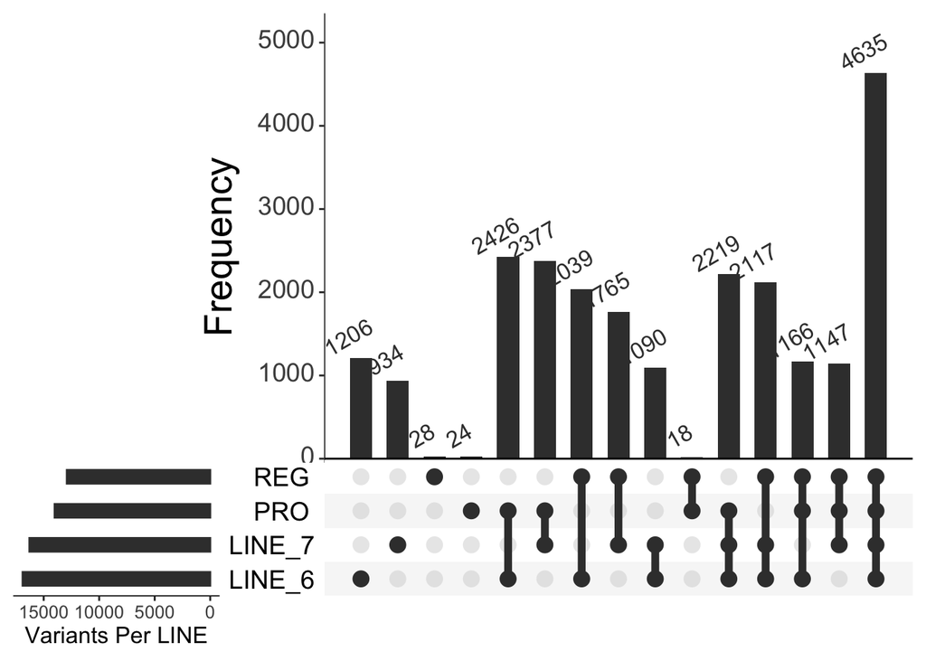

```r
########################################################################
########## Visualization of SNPs with Upset ############################
########################################################################
# Create a matrix of just the genotype data
geno <- L67RP_anne[,11:ncol(L67RP_anne)] %>% transpose() %>% as.matrix()
# Grab a transposed df to double check naming orientation
L67RP_tp <- L67RP_anne[,11:ncol(L67RP_anne)] %>% transpose()

# Extract the sample names
SAMPLE <- names(L67RP_anne[,11:ncol(L67RP_anne)])

# Make the rownames to IDs for now
L67RP_anne$ID <- row.names(L67RP_anne)

# Select the appropriate columns
L67RP_upset <- L67RP_anne %>% dplyr::select(ID,LINE_6, LINE_7, REG, PRO)

# Remove the ID column
L67RP_anne <- L67RP_anne %>% dplyr::select(-ID)

# Replace 0.5 values
L67RP_upset[L67RP_upset == 0.5] <- 1

# Visualize intersections with UpSet
upset(data.frame(L67RP_upset), nsets = 4, number.angles = 30, point.size = 4, line.size = 2,
      mainbar.y.label = "Frequency", sets.x.label = "Variants Per LINE",
      text.scale = c(2.5, 2, 1.5, 1.4, 2, 2))
```

```r
################################################################################
#####     K means cluster approach #############################################
################################################################################
# Code copied/adjusted from Kevin Falk: https://www.youtube.com/watch?v=cC6lMr8LgPQ&list=PLYX_up7DciW3r3VOmzRxKAyrZBB_eHLmy&index=9&t=0s

# Create a matrix of just the genotype data
#geno = as.matrix(L67RP_anne[,11:ncol(L67RP_anne)])
# transpose the genotypes to fit genind function
#geno_trans <- data.frame(transpose(as_tibble(geno)))
# Convert a data.frame of allele data to a genind object
#genind_geno <- df2genind(geno_trans, ploidy=2,sep='\t')
#genind_geno_b <- df2genind(data.frame(geno), ploidy=2,sep='\t')
# Perform k means with different values of k (here we'll use either 2,3, or 4)
#find.clusters(genind_geno, max.n =3, n.pca = 200, scale = FALSE)
# Increase k until no increase in fit (e.g. measure of fit interpreted by decrease in BIC)
#phenogrp <- find.clusters(x, max.n=2, n.pca=200, scale=TRUE)


################################################################################
#####     LD, Fst, and genetic distance params      ############################
################################################################################
# Code copied/adjusted from Kevin Falk: https://www.youtube.com/watch?v=VbHiYvseNdU&list=PLYX_up7DciW3r3VOmzRxKAyrZBB_eHLmy&index=7

# Create a matrix of just the genotype data
#geno <- L67RP_anne[,11:ncol(L67RP_anne)] %>% transpose() %>% as.matrix()
# Grab a transposed df to double check naming orientation
#L67RP_tp <- L67RP_anne[,11:ncol(L67RP_anne)] %>% transpose()

# Extract the sample names
#samples <- names(L67RP_anne[,11:ncol(L67RP_anne)])

# Examine SNP data
#head(geno)
```

## Visualization of Genotype Variance Across Samples with PCA

```r
################################################################################
#####     PCA of Genotypes      ################################################
################################################################################
# Code copied/adjusted from Kevin Falk: https://www.youtube.com/watch?v=dyy0nWOqKHI&list=PLYX_up7DciW3r3VOmzRxKAyrZBB_eHLmy&index=6

# Create a matrix of just the genotype data
geno <- L67RP_anne[,11:ncol(L67RP_anne)] %>%
        transpose() %>% as.matrix()
# Grab a transposed df to double check naming orientation
L67RP_tp <- L67RP_anne[,11:ncol(L67RP_anne)] %>% transpose()

# Examine SNP data
#geno[1:4,1:20]

# Make sure there are no NA values
is.na(geno) %>% sum()
```

```
## [1] 0
```

Number of variants removed that did not demonstrate any variance (i.e. they were all identical)

```r
# Find columns with zero variance
length(which(apply(geno, 2, var)==0))
```

```
## [1] 4417
```

```r
# Remove columns with zero variance
geno_pca <- geno[ , apply(geno, 2, var) != 0]

# Examine the data
#geno_pca[1:4,1:20]
```

Dimensions of dataset:

```r
# How many variants?
dim(geno_pca)
```

```
## [1]     4 18776
```

```r
# Calculate principle components
PCAs <- prcomp(geno_pca, scale. = TRUE)
```

A Summary of the Principle Components

```r
summary(PCAs)
```

```
## Importance of components:
##                            PC1     PC2     PC3       PC4
## Standard deviation     92.7666 74.9620 67.4615 7.187e-12
## Proportion of Variance  0.4583  0.2993  0.2424 0.000e+00
## Cumulative Proportion   0.4583  0.7576  1.0000 1.000e+00
```

[figure not shown]

```r
# Loadings: rotated data -- the centered data X the rotation matrix
PCA_loadings = PCAs$x

# Extract the sample names
SAMPLE <- names(L67RP_anne[,11:ncol(L67RP_anne)])

# Merge the PCA loadings with annotation (meta) data
PCA_loadings <- as_tibble(cbind(SAMPLE, PCA_loadings))
names(PCA_loadings)[1] <- 'SAMPLE'

# Plot the PCA plot using ggplot2
ggplot(PCA_loadings, aes(x = PC1, y = PC2, color = SAMPLE, size = 2)) +
        geom_point(alpha=1) +
        labs(x = "PC1 (45.83%)", y = "PC2 (29.93%)")
```

## Example Sampling of Variants (e.g. Unique to Regressor Line)

```r
################################################################################
#####     Sample Unique Variants      ##########################################
################################################################################

# Grab variants unique only to Regressor Line
LR_anne <- L67RP_anne %>% filter(LINE_6 == 0 & LINE_7 == 0 & PRO == 0)

# Vizulaize the data
```

Number of genotypes unique to regressor line

```r
LR_UQ <- LR_anne %>% dplyr::select(CHROM,POS,REF,ALT) %>% unique()
dim(LR_UQ)[1]
```

```
## [1] 13
```

All the unique Regressor-specific variants (note redundent positions in annotations)

```r
LR_anne %>% dplyr::select(-STRAND, -IMPACT) %>% data.frame()
```

```
##    CHROM       POS REF ALT             CONSEQUENCE SYMBOL SIFT  GT LINE_6
## 1      1 169032446   G C,T          intron_variant FNDC3A      2/2      0
## 2      1 169032446   G C,T          intron_variant FNDC3A      1/1      0
## 3      1 169039609   T A,C          intron_variant FNDC3A      2/2      0
## 4      1 169039609   T A,C          intron_variant FNDC3A      1/1      0
## 5      2  80036105   A G,T   upstream_gene_variant SRD5A1      2/2      0
## 6      2  80036105   A G,T   upstream_gene_variant SRD5A1      1/1      0
## 7      2  80036105   A G,T      synonymous_variant  NSUN2      2/2      0
## 8      2  80036105   A G,T      synonymous_variant  NSUN2      1/1      0
## 9      3   7510221   T C,A          intron_variant   FSHR      2/2      0
## 10     3   7510221   T C,A          intron_variant   FSHR      0/1      0
## 11     3   7516704   A G,T          intron_variant   FSHR      2/2      0
## 12     3   7516704   A G,T          intron_variant   FSHR      1/1      0
## 13     3 102682352   T A,C      synonymous_variant   APOB      2/2      0
## 14     3 102682352   T A,C      synonymous_variant   APOB      1/1      0
```

[output cut: 47 more lines]

Summary of unique Regressor-specific variants

```r
summary(LR_anne)
```

```
##      CHROM            POS            REF         ALT         STRAND
##  Min.   : 1.00   Min.   :   789469   A:16   G,T    :10   Min.   :-1.0
##  1st Qu.: 2.25   1st Qu.:  3068294   C: 2   A,C    : 6   1st Qu.: 1.0
##  Median : 5.00   Median : 12989905   G: 4   T,C    : 4   Median : 1.0
##  Mean   : 7.20   Mean   : 46098087   T: 8   T,G    : 4   Mean   : 0.6
##  3rd Qu.:11.75   3rd Qu.: 80036105          C,A    : 2   3rd Qu.: 1.0
##  Max.   :19.00   Max.   :169039609          C,T    : 2   Max.   : 1.0
##                                             (Other): 2
##                   CONSEQUENCE      IMPACT       SYMBOL
##  intron_variant         :18   LOW     : 6   DNAH1  : 4
##  synonymous_variant     : 6   MODERATE: 0   FNDC3A : 4
##  upstream_gene_variant  : 4   MODIFIER:24   FSHR   : 4
##  downstream_gene_variant: 2                 ABHD2  : 2
##  3_prime_UTR_variant    : 0                 APOB   : 2
##  5_prime_UTR_variant    : 0                 BBS2   : 2
##  (Other)                : 0                 (Other):12
##                                SIFT      GT         LINE_6      LINE_7
##                                  :30   0/0: 1   Min.   :0   Min.   :0
##  deleterious_low_confidence(0.02): 0   0/1: 2   1st Qu.:0   1st Qu.:0
##  deleterious(0.01)               : 0   1/1:11   Median :0   Median :0
##  deleterious(0.02)               : 0   1/2: 1   Mean   :0   Mean   :0
##  deleterious(0.04)               : 0   2/1: 1   3rd Qu.:0   3rd Qu.:0
##  deleterious(0)                  : 0   2/2:14   Max.   :0   Max.   :0
##  (Other)                         : 0
##       REG              PRO
##  Min.   :0.0000   Min.   :0
##  1st Qu.:1.0000   1st Qu.:0
##  Median :1.0000   Median :0
##  Mean   :0.8667   Mean   :0
##  3rd Qu.:1.0000   3rd Qu.:0
##  Max.   :1.0000   Max.   :0
##
```

This script merely shows the ability to perform some of the analyses we discussed, and demonstrates that the genotype overlap seems reasonable. I think the data seems to be in ‘good shape’ for exploration and verification.